# Introduction

## Macrophages: the "big eaters" of our immune system

Macrophages are differentiated immune cells ubiquitously present under homeostatic conditions in different tissues and body compartments, where they play pivotal roles as a first defense line of the innate immune system against infections. Macrophages can derive from different immune cell precursors, which colonize different organs, depending on the environmental stimuli differentiate into macrophages which in turn are activated. Once activated, macrophages can secrete specific cytokines and other factors to participate in diverse functions, both pro-inflammatory and pro-reparatory.

### Origin and function of macrophages

For a long time, macrophages have been though to mainly derive from circulating monocytes. This cell population is formed mainly in the bone marrow. Once formed, monocytes are released in the peripheral blood from which they can reach different body compartments, to replenish tissue macrophage populations (Fig.1) (Gordon, S. et al., 2005).

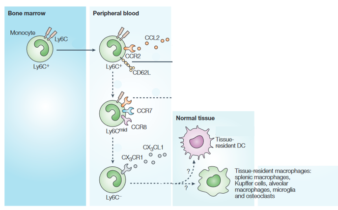

###### Fig.1. Development and function of monocyte subsets in mice (adapted from Gordon, S. et al., 2005).

However, this view has been implemented along the years. Evidencies demonstreated that in many murine models body compartments (such as brain, liver, skin, lungs, etc.) the macrophages here located derive from the yolk sac or the fetal liver, not requiring the presence of circulating monocytes precursors, in contrast with the previous model. In humans, the same dual origin is valid, even if we can speculate about the fact that, since the proliferation induced by colony stimulating factor 1 (CSF-1) is less efficient than in mice, maybe circulating monocytes could play an important role. Nevertheless, more blood-borne precursors can be recruited from the peripheral blood to repopulate tissue-resident macrophages in the inflamed tissues. Further studies are needed in order to shed light on the way by which macrophages are originated, including techniques of cell tracking using transparent animal models, such as the zebrafish.

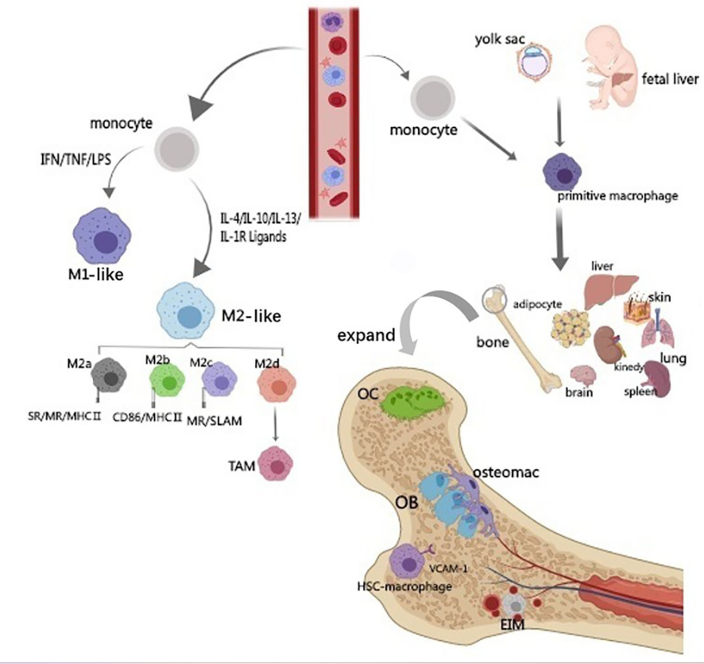

###### Fig.2 Origin and classification of macrophages.

As the name suggests, macrophages are involved in phagocytosis, an important biological process involved in the rapid response against infections. In fact, they cooperate with other innate immune cells to guarantee a first line defense against external and internal pathogens. Macrophages present at the plasma membrane or in endocytic compartments a repertoire of innate immunity receptors, such as Toll Like Receptors (TLRs) and lectin-like receptors. These receptors can sense different stimuli related to infections or damages. Upon the receptor-mediated recognition, macrophages react via the interaction with other innate immune cells (Molgora M. et al., 2018) and/or by providing components of the humoral immunity, such as complement components and fluid phase recognition molecules (PRM) (Garlanda C. et al., 2005).

But also, macrophages are crucial for the maintenance of tissue homeostasis, the removal of senescent cells and the repair of tissues after inflammation. In this sense, it could be easily understood that this immune cell population is involved in both inflammation but also repair of tissues after damages, to recover the physiological conditions present before the inflammation.

Depending on the tissue in which they are located, in fact, macrophages play pivotal functions in organ development, metabolism, maintenaince of physiological functions, provide a good niche environment for stem cells, etc. Once infection states or other environmental perturbations occur, they can be activated and work as innate immune cells in concert with other players of the immune system to counteract the harmful stimuli and restore the physiological functions (Fig.3) (Locati M. et al., 2020).

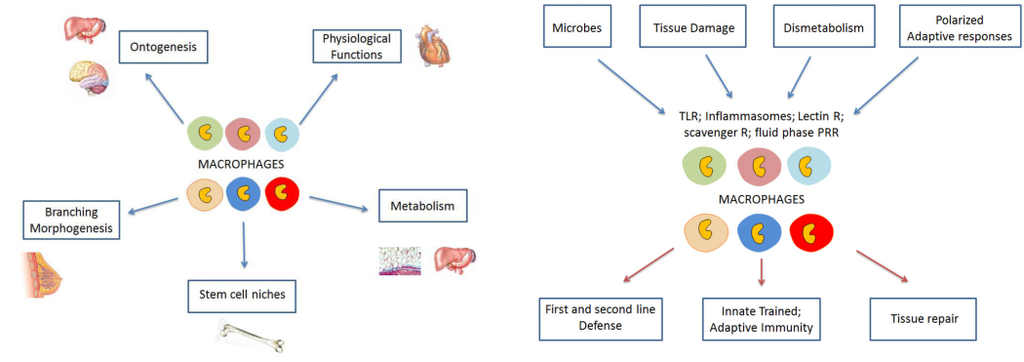

###### Fig.3 Homeostatic functions of macrophages and response to environmental perturbations to restore homeostasis.

For this reason, heterogenicity is one of the main characteristics of this immune cell population, that guarantees that these specialized cells accomplish both inflammatory and healing roles and overall maintain tissue homeostasis in the different anatomical locations where are localized. It is important to point out that, depending on the way by which resident macrophages are originated in the different tissues (either by circulating monocytes replenishment or in-tissue origin) and the stimuli received to mediate their activation, the activities played by the resident macrophages themselves will change.

### Activation states of macrophages

Among all the different categories of tissue-resident macrophages, for the aim of this work I have focused my attention on the inflammatory monocyte-derived macrophages. It has been demonstrated that they derive from inflammatory circulating monocytes which are recruited and differentiated into macrophages at the site of the lesion. By in vitro characterization studies, it has been discovered that different stimuli (mainly different cytokines and interleukings sensed) can elicit macrophages to acquire different activation states, which are schematized in Fig. 4. (Taylor, P. R. et al., 2005).

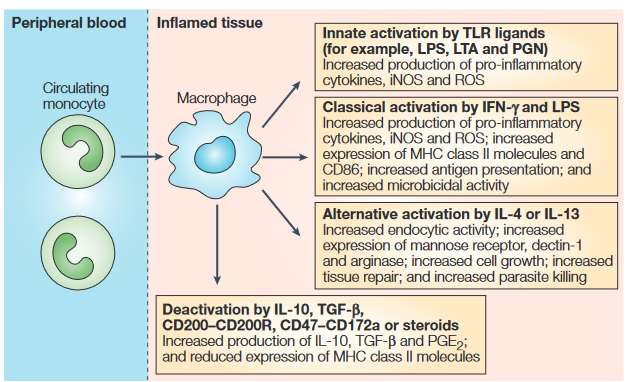

###### Fig.4 Macrophage heterogeneity during inflammation.

Polarization is the process by which, upon different environmental signals, macrophages are activated and acquire different functions. Therefore, polarization leads to the definition of two main categories of macrophages, distinguished by the set of cytokines and factors activating them, the cytokines in turn released and so the function played. The first group is referred as M1 macrophages and the second as M2 macrophages. However, they are currently called M1-like and M2-like (Biswas, S. K., and Mantovani, A., 2010). Also, other kind of activated statuses can be defined, but for the aim of this study I decided to report only two of them.

#### Classical activation of macrophages

The classical activation state or M1-macrophage activation is induced when interferon-γ (IFN-γ) and lipopolysaccharide (LPS). Due to the nature of the stimuli, the M1 activation state is related to high microbicidal activity, pro-inflammatory cytokines production and cellular immunity. The classical activation system was characterized in the 1960s. Different studies demonstrated that T helper 1 (TH-1)-type lymphocytes and natural-killer (NK) cells secrete IFN-γ and different cytokines (among them interleukin-12 (IL-12) and interleukin-18 (IL-18)) that, in presence of the bacterial LPS were responsible for the activation of M1 macrophages, thus promoting an anti-microbic immune activity. M1 macrophages in this way activated release pro-inflammatory cytokines, nitric oxide (NO) and reactive oxygen species (ROS) to counteract harmful microbes (Fig.5).

Also tumor necrosis factor-α (TNFα) plays a role in macrophage inflammatory response. In fact, TNFα is not only secreted by macrophages once IFN-γ or other pro-inflammatory stimuli have activated M1 macrophages, but also it can establish a feed-forward loop to sustain inflammation. In fact, the exogenous addition of TNFα can induce a stronger activation of NF-kB, which induces a stronger production of toxic oxygen species and NO at the inflammation site (Parameswaran N. et al., 2010). Moreover, Yarilina and colleagues demonstrated that after 2 days of TNFα stimulation, the molecule is able to establish an autocrine loop sustaining inteferon-β (IFN-β) production, which acts synergistically to with the canonical TNFα pathway, inducing the translation of inflammatory molecules (Yarilina A. et al., 2008).

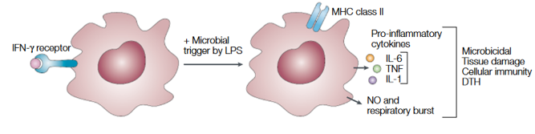

###### Fig.5 Classical activation of macrophages.

#### Alternative activation of macrophages

The alternative activation state, also called M2 macrophage activation, is induced by the presence of interleukin-4 (IL-4) and interleukin-13 (IL-13) and correlates mainly to tissue repair, anti-parasitic activity, humoral immunity and increased cell growth. These cytokines are mainly produced by T helper 2 (TH-2)-type lymphocytes (but also other not well defined sources are present in our organism) and they target macrophages through the binding of the same receptor, the IL-4 receptor (IL-4R). Thanks to in vitro studies, it has been possible to demonstrate that macrophages treated with recombinant IL-4 and IL-13 present an increased expression of the MHC class II, enhaced mannose receptor activity, inhibition of the pro-inflammatory cytokines secretion and increased expression of intracellular enzymes, such as arginase (Gordon, S., 2003).

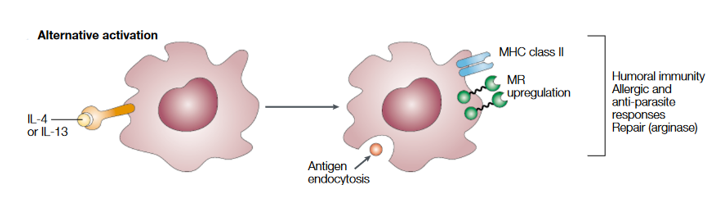

###### Fig.6 Alternative activation of macrophages.

Even if the M1/M2 separation is considered an intrisic characteristic of macrophages, mediating the passage from inflammation to healing (Mills CD., 2012), this class of immune cells is very plastic and can even acquire different activation states not only including repair-like and inflammatory ones but also intermediate states of activation. The acquisition of different activation states is determined by the stimulus provided to macrophages (so the type of cytokines to which they are exposed), which leads to the activation of different intracellular pathways that can end up with the expression of different genes and, as a consequence, different proteins will be synthesized and different functions will be performed in response to the stimulus received. For these reasons, it is interesting to analyze gene expression profile of macrophages activated upon different stimuli, to define which will be the biological functions presumably played by the activated macrophages. In fact, since macrophages are involved in both repair and inflammation, understanding which kind of stimuli are able to induce one or both of these functions (or maybe others) could be interesting for example in the field of autoimmune diseases, to find new targets to counteract these pathological states.

In the present study, bone-marrow derived macrophages (BMDMs) from murine models have been treated with two combinations of cytokines: the first group with both IL-4 and IL-13, the second group with IL-4, IL-13 and TNFα. IL-4 and IL-13, as already demonstrated, are well-known cytokines mediating the alternative activation of macrophages and leading to repair-like function. In the second treatment group the reasearches added also TNFα, which instead plays a more pro-inflammatory role. The aim of the study was to characterize the genes differentially expressed in these two treament groups, compared to an untreated control, that could maybe mediate different and intermediate activation states of macrophages, thus different functions played by these innate immune system cells.

# Data description

The researchers have analyzed murine bone marrow derived macrophages (BMDM) from C57BL/6 male animals. The BMDMs were divided in 3 treatment groups: untreated (controls), treated with IL-4 and IL-13, and treated with IL-4, IL-13 and TNFα. For each treatment condition the researchers analyzed six replicates, for a total of 18 samples.

After having done the RNA extraction, bulk RNA-sequencing was performed. Alignment has been performed with STAR v2.5.2 using mm10/GRCm38 genome reference. Read counts have been obtained with featureCounts v1.5.1. For quantification, transcript annotation files from Ensembl version 86 were used, which corresponds to GENCODE M11 for mouse. Gene expression levels were quantified with the above annotations, using RSEM (v1.3.0) and featureCounts (v1.5.1). Also FastQC: A Quality Control Tool for High Throughput Sequence Data has been performed to evaluate the overall quality of the experiment.

A matrix table with raw gene counts for every gene and every sample has been obtained, provided on GEO website and used in this work for the analysis.

# Results

I set the working directory in which the raw count matrix is contained

```r
setwd("/bin/Exam_FT")
```

## Data normalization

Data normalization is needed for visualization only of bulk RNA-seq data, since for the differential expression (DE) analysis un-normalized counts are used (explained why later). Data normalization must be performed before data visualization, otherwise the differences, the variance among the samples that we are visulizing cannot be compared to each other. The counts associated to each gene (contained in the raw matrix) can be normalized using different methods. In this course we have used the counts per million (CPM) normalization method, but others such as TPM, FPK and RPKM can be as well used. Performing CPM normalization means that the ratio among the counts of each gene over the total number of counts multiplied by 10^6 is done.

Normalization of the data requires the convertion of the counts contained in the raw count matrix into counts per million (CPM) using the edgeR package of Bioconductor. First, I converted the dataset into a dataframe x

```r
x = read.table("GSE182024_Raw_gene_counts_matrix.txt", sep="\t", header=TRUE, row.names=1)
class(x)
head(x)
```

'data.frame'

A data.frame: 6 × 18

|  | BMDM_Control_rep_1 <int> | BMDM_IL4_IL13_rep_1 <int> | BMDM_IL4_IL13_TNFa_rep_1 <int> | BMDM_Control_rep_2 <int> | BMDM_IL4_IL13_rep_2 <int> | BMDM_IL4_IL13_TNFa_rep_2 <int> | BMDM_Control_rep_3 <int> | BMDM_IL4_IL13_rep_3 <int> | BMDM_IL4_IL13_TNFa_rep_3 <int> | BMDM_Control_rep_4 <int> | BMDM_IL4_IL13_rep_4 <int> | BMDM_IL4_IL13_TNFa_rep_4 <int> | BMDM_Control_rep_5 <int> | BMDM_IL4_IL13_rep_5 <int> | BMDM_IL4_IL13_TNFa_rep_5 <int> | BMDM_Control_rep_6 <int> | BMDM_IL4_IL13_rep_6 <int> | BMDM_IL4_IL13_TNFa_rep_6 <int> |
| --- | --- | --- | --- | --- | --- | --- | --- | --- | --- | --- | --- | --- | --- | --- | --- | --- | --- | --- |
| ENSMUSG00000000001 | 3204 | 4701 | 3885 | 2922 | 3737 | 3336 | 2359 | 3657 | 3925 | 2256 | 3880 | 3795 | 2512 | 3401 | 3400 | 2634 | 3880 | 3756 |
| ENSMUSG00000000003 | 0 | 0 | 0 | 0 | 0 | 0 | 0 | 0 | 0 | 0 | 0 | 0 | 0 | 0 | 0 | 0 | 0 | 0 |
| ENSMUSG00000000028 | 729 | 777 | 99 | 267 | 460 | 83 | 113 | 380 | 93 | 196 | 606 | 102 | 109 | 292 | 94 | 154 | 474 | 146 |
| ENSMUSG00000000031 | 0 | 0 | 0 | 1 | 0 | 0 | 0 | 0 | 0 | 9 | 2 | 0 | 0 | 2 | 0 | 0 | 8 | 1 |
| ENSMUSG00000000037 | 17 | 13 | 3 | 9 | 12 | 6 | 2 | 11 | 2 | 1 | 25 | 6 | 6 | 10 | 2 | 5 | 11 | 4 |
| ENSMUSG00000000049 | 0 | 1 | 0 | 0 | 0 | 0 | 1 | 0 | 0 | 0 | 0 | 0 | 1 | 0 | 2 | 0 | 1 | 1 |

I convert the dataframe x into a matrix y (since edgeR requires a matrix)

```r
y=as.matrix(x, rownames.force=NA)
class(y)
```

1. 'matrix'

2. 'array'

I load the library

```r
library(edgeR)
```

I use the edgeR package to make the conversion into CPM of the matrix y

```r
counts2cpm <- edgeR::cpm(y)
```

I save the results into a txt file

```r
write.table(counts2cpm, file = "BMDM_counts2cpm.txt", sep ="\t", col.names=NA)
```

## Data visualization

Once we have normalized the data, we can visualize them. To do this we can perform a Principal Component Analysis (PCA). PCA is useful because it allows the visualization of the variance between the samples and therefore the evaluation of the overall experiment quality. PCA allows to visualize the data doing a linear space reduction. Generally, depending on the number of conditions provided in the dataset, we can have a representation of the data in a multi-dimensional space, that is not handable and useful. To reduce the multi-dimension into a bidimensional (2D) representation of the data, we can use different linear space reduction methods, such as PCA. PCA calculates the principal components (PCs) that will be used in the 2D graph. In the case of this dataset, we have 18 conditions, meaning 18 dimensions in which data could be visualized, something that is not handable. For this reason, the PCA calculates 18 PCs and uses pairs of them to visualize in a 2D plot the variation among the samples.

I save in the variable data the CPM normalized counts as a dataframe. Then I make the logarithmic transformation of the normalized counts adding a +1 pseudocount (to avoid the presence of +/- infinite due to the log-transformation of possible 0 values present in the normalized counts). I use the function prcomp to calculate the PCs of the transposed dataframe. I save the results in the variable pca.

```r
data = read.table("BMDM_counts2cpm.txt", sep="\t", header = TRUE, row.names=1)
data=log2(data+1)
pca <- prcomp(t(data))
```

Looking at the summary of the pca calculated as above, we can notice that for each component are indicated the standard deviation, the proportion of variance and the cumulative proportion.

```r
summary(pca)
```

```
Importance of components:
                           PC1     PC2      PC3     PC4     PC5     PC6    PC7
Standard deviation     53.0632 30.0972 16.73071 9.32315 7.45801 5.99005 5.6049
Proportion of Variance  0.6362  0.2047  0.06325 0.01964 0.01257 0.00811 0.0071
Cumulative Proportion   0.6362  0.8409  0.90411 0.92375 0.93632 0.94442 0.9515
                           PC8     PC9    PC10    PC11    PC12    PC13    PC14
Standard deviation     5.15847 5.01046 4.83588 4.74397 4.64601 4.51595 4.45221
Proportion of Variance 0.00601 0.00567 0.00528 0.00508 0.00488 0.00461 0.00448
Cumulative Proportion  0.95753 0.96321 0.96849 0.97358 0.97845 0.98306 0.98754
                          PC15    PC16    PC17      PC18
Standard deviation     4.35256 4.27005 4.23956 1.953e-13
Proportion of Variance 0.00428 0.00412 0.00406 0.000e+00
Cumulative Proportion  0.99182 0.99594 1.00000 1.000e+00
```

Now I want to graphically represent the PCA as a 2D plot. First, I calculate the percentage variance from the standard deviation

```r
pca.var <- pca$sdev^2
pca.var.per <- round(pca.var/sum(pca.var)*100, 1)
```

Moreover, pca$x contains the PCs values for the different experimental conditions

```r
head(pca$x)
```

A matrix: 6 × 18 of type dbl

|  | PC1 | PC2 | PC3 | PC4 | PC5 | PC6 | PC7 | PC8 | PC9 | PC10 | PC11 | PC12 | PC13 | PC14 | PC15 | PC16 | PC17 | PC18 |
| --- | --- | --- | --- | --- | --- | --- | --- | --- | --- | --- | --- | --- | --- | --- | --- | --- | --- | --- |
| BMDM_Control_rep_1 | -45.61728 | -2.409926 | -55.7789320 | 6.0841324 | -8.357553 | -6.205722 | -2.692951 | 2.486532 | -1.615892 | -1.3773877 | 3.1410278 | -0.9702579 | 0.1527285 | -1.5891507 | 1.813138 | -0.01325107 | 0.3713467 | 6.107215e-13 |
| BMDM_IL4_IL13_rep_1 | -12.61264 | -45.229274 | -18.4294085 | -4.4821498 | 1.651895 | 10.061153 | 5.656580 | -4.300892 | -3.079684 | 7.1790761 | -6.7910498 | -1.0631916 | -3.5024139 | 4.5214626 | -3.182773 | -2.47624329 | 3.0723696 | 3.283537e-13 |
| BMDM_IL4_IL13_TNFa_rep_1 | 69.12957 | 13.120911 | -9.5259754 | -7.3280937 | 5.846317 | 2.335114 | 3.961485 | -7.899356 | -8.369673 | -8.1110477 | -0.4491572 | 5.4465729 | -0.3638358 | -4.1620757 | 1.955685 | 4.97084150 | -1.8525634 | -2.110874e-12 |
| BMDM_Control_rep_2 | -59.41739 | 26.551734 | -3.9117860 | -0.8312614 | 5.473028 | 4.811915 | -10.047029 | 1.040550 | 3.490140 | -3.5000463 | -2.4212540 | 6.1831513 | 3.1283640 | 3.6933421 | -9.635121 | 2.30169237 | -1.4896924 | -7.752728e-13 |
| BMDM_IL4_IL13_rep_2 | -17.67129 | -38.898547 | 2.4458768 | -3.9427772 | 5.869058 | 8.337945 | -5.137188 | 3.938351 | 4.115685 | -0.9897688 | 2.4752875 | 5.1996681 | 1.2955721 | -1.7965215 | 9.965058 | -5.55429377 | -3.4807470 | -1.422485e-13 |
| BMDM_IL4_IL13_TNFa_rep_2 | 68.35696 | 18.423859 | -0.7116864 | -3.1325749 | 2.451233 | 7.703622 | -8.194428 | 1.559444 | 1.349748 | -3.5415877 | 2.4637891 | -12.5387771 | -2.2461285 | 0.9143999 | 1.129769 | 1.86733991 | 4.6544308 | -1.646477e-12 |

By using the library ggplot2 I create a fancy PCA plot using as input the dataframe pca.data that presents 3 columns: the samples -which are the rownmanes of the dataframe data, so our experimental condition with the 6 replicates each-; and the PC1 and PC2 values for each experimental condition, respectively named X and Y.

```r
library(ggplot2)
pca.data <- data.frame(Sample=rownames(pca$x),
                       X=pca$x[,1],
                       Y=pca$x[,2])
dim(pca.data)
head(pca.data)
```

1. 18

2. 3

A data.frame: 6 × 3

|  | Sample <chr> | X <dbl> | Y <dbl> |
| --- | --- | --- | --- |
| BMDM_Control_rep_1 | BMDM_Control_rep_1 | -45.61728 | -2.409926 |
| BMDM_IL4_IL13_rep_1 | BMDM_IL4_IL13_rep_1 | -12.61264 | -45.229274 |
| BMDM_IL4_IL13_TNFa_rep_1 | BMDM_IL4_IL13_TNFa_rep_1 | 69.12957 | 13.120911 |
| BMDM_Control_rep_2 | BMDM_Control_rep_2 | -59.41739 | 26.551734 |
| BMDM_IL4_IL13_rep_2 | BMDM_IL4_IL13_rep_2 | -17.67129 | -38.898547 |
| BMDM_IL4_IL13_TNFa_rep_2 | BMDM_IL4_IL13_TNFa_rep_2 | 68.35696 | 18.423859 |

The argument given to ggplot is the dataframe pca.data. The aesthetics (aes) specified are as x the PC1 values and as y the PC2 values which are grouped based on Sample, that corresponds to the Sample column of the dataframe pca.data, that, as already said, contains the different treatments conditions replicates. geom_point parameters allows the representation of the data as a scatterplot.

Using ggplot, I obtain a 2D graph in which on the x-axis the PC1 percentage variation is reported and the PC2 percentage variation is reported in the y-axis. Each dot corresponds to a replicate of the 3 different experimental conditions (6 control replicates, 6 IL-4 and -13 treatment replicates, 6 IL-4, -13 and TNFα treatment replicates). The result of the analysis are reported in the BMDM_pca.pdf file and also reported below as an image.

[figure not shown]

```r
ggplot(data=pca.data, aes(x=X, y=Y, color=Sample)) +
  geom_point() +
  scale_color_manual(labels = c(rep("ctrl",6), rep("IL4_13",6), rep("IL4_13_TNFa",6)),
                     values = c(rep("blue",6), rep("red",6), rep("green",6))) +
  xlab(paste("PC1 - ", pca.var.per[1], "%", sep="")) +
  ylab(paste("PC2 - ", pca.var.per[2], "%", sep="")) +
  ggtitle("BMDM PCA")
ggsave(filename="BMDM_pca.pdf")
```

###### PCA analysis performed on CPM normalized, log-transformed counts

By looking at the results reported above, we can notice that the three groups are separated between each other. This separation is mainly on the first component (PC1), which in fact accounts for 63.6% of the variation among the samples. These results suggest that the variation among the samples is mainly represented by the first component which explains the majority of the variation among the samples once different treatment conditions are applied. So that the overall quality of the experiment is quite good.

To confirm that the most of the variation among the sample comes from the 2 first components (PC1 mainly and PC2 less) we can draw a scree plot. The scree plot is made with the function barplot, that uses as argument the variance percentage associated to each PC to determine the height of the 18 bars, representing the 18 PCs. As x-axis we have the different PCs and as y-axis the percent vaiation. I save the scree plot into a pdf file named BMDM_screeplot.pdf.

```r
pdf("BMDM_screeplot.pdf")
barplot(pca.var.per, main="Scree Plot", xlab="Principal Component", ylab="Percent Variation", ylim = c(0,70))
dev.off()
```

**png:** 2

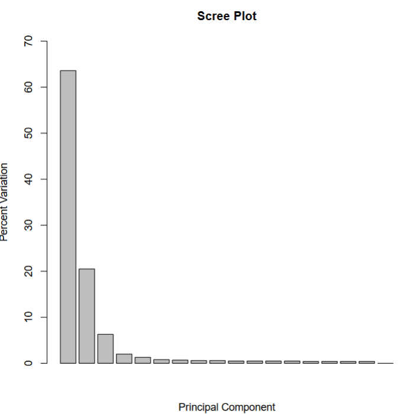

###### Scree plot representing the percent variation associated to each PC

I can then use the loading scores (which are the proportions of the impact of each gene on a specific PC, used to calculate the eigenvalues) to calculate the genes that impact on the positioning of the samples in the PCA plot. The prcomp function calls the loading scores rotation and they are present for each PCs. Since PC1 accounts for about 63% of the variation of the data I consider its loading scores

```r
loading_scores <- pca$rotation[,1]
```

Since I want to understand all the genes that have made the samples positioning on the right or on the left of the graph, presenting in accordance positive or negative values, I consider the absolute values of the loading scores to get further insight on all the set of genes determining this position

```r
gene_scores <- abs(loading_scores)
```

Then I rank the gene scores from the top to the bottom

```r
gene_score_ranked <- sort(gene_scores, decreasing=TRUE)
```

I then get the names of the top 10 genes with the largest loading score magnitude

```r
top_10_genes_names <- names(gene_score_ranked[1:10])
top_10_genes_names
```

1. 'ENSMUSG00000016283'

2. 'ENSMUSG00000031779'

3. 'ENSMUSG00000031613'

4. 'ENSMUSG00000017737'

5. 'ENSMUSG00000022126'

6. 'ENSMUSG00000030789'

7. 'ENSMUSG00000027737'

8. 'ENSMUSG00000031444'

9. 'ENSMUSG00000024164'

10. 'ENSMUSG00000029379'

Finally, it is possible to evaluate which genes have positive or negative loading scores, determining respectively that the samples are positioned to the right or left part of the PCA plot. The results are saved into a txt file. It can be noticed that there is 1 gene presenting a negative loading score, instead all the other show positive values. This result is in accordance with the fact that there is a greater separation on the PC1 mainly between the control and IL-4 and -13 treatment compared to the IL-4, -13 and TNFα, that is more moved on the right of the graph.

```r
top_10_genes = pca$rotation[top_10_genes_names,1]

write.table(top_10_genes, file = "BMDM_top10genes.txt", sep ="\t", col.names=NA)
```

## Differential expression analysis

Once we have normalized the data and visually evaluated the overall quality of the experiment considering the variance between the samples, we can proceed with the differential expression analysis, that will indicate which genes are differentially expressed between the samples once a condition is applied. In the case of this dataset, we want to understand which genes are differentially expressed once we treat BMDMs with IL-4 and IL-13 compared to a control, and which genes are differentially expressed once cells are treated with IL-4, IL13 and TNFα. Also, it could be interesting to visualize if some genes are in common.

The library required, DESeq2, is a Bioconductor package that does not need normalized counts. In fact, DESeq2 internally corrects for library size, so transformed or normalized values such as counts scaled by library size should not be used as input.

```r
library(DESeq2)
```

I select the columns of the dataframe x (which is simply the dataset containing the raw counts converted into a dataframe) that correspond to the 6 control replicates and the 6 replicates of the treatment with IL-4 and IL-13.The selected columns are saved into a dataframe ctrl.int whose the first 6 columns are the controls and the last 6 columns are the samples treated with IL-4 and IL-13. ctrl.int is the dataframe on which I will made the DE analysis to understand which genes are differentially expressed once we treat BMDMs with IL-4 and -13 compared to control.

```r
ctrl.int <- data.frame(x[,c(1,4,7,10,13,16,2,5,8,11,14,17)], row.names = rownames(x))
head(ctrl.int)
```

A data.frame: 6 × 12

|  | BMDM_Control_rep_1 <int> | BMDM_Control_rep_2 <int> | BMDM_Control_rep_3 <int> | BMDM_Control_rep_4 <int> | BMDM_Control_rep_5 <int> | BMDM_Control_rep_6 <int> | BMDM_IL4_IL13_rep_1 <int> | BMDM_IL4_IL13_rep_2 <int> | BMDM_IL4_IL13_rep_3 <int> | BMDM_IL4_IL13_rep_4 <int> | BMDM_IL4_IL13_rep_5 <int> | BMDM_IL4_IL13_rep_6 <int> |
| --- | --- | --- | --- | --- | --- | --- | --- | --- | --- | --- | --- | --- |
| ENSMUSG00000000001 | 3204 | 2922 | 2359 | 2256 | 2512 | 2634 | 4701 | 3737 | 3657 | 3880 | 3401 | 3880 |
| ENSMUSG00000000003 | 0 | 0 | 0 | 0 | 0 | 0 | 0 | 0 | 0 | 0 | 0 | 0 |
| ENSMUSG00000000028 | 729 | 267 | 113 | 196 | 109 | 154 | 777 | 460 | 380 | 606 | 292 | 474 |
| ENSMUSG00000000031 | 0 | 1 | 0 | 9 | 0 | 0 | 0 | 0 | 0 | 2 | 2 | 8 |
| ENSMUSG00000000037 | 17 | 9 | 2 | 1 | 6 | 5 | 13 | 12 | 11 | 25 | 10 | 11 |
| ENSMUSG00000000049 | 0 | 0 | 1 | 0 | 1 | 0 | 1 | 0 | 0 | 0 | 0 | 1 |

Then I do the same for the second condition, so that I select the columns of dataframe x corresponding to the 6 control replicates and the 6 replicates of treatment with IL-4, -13 and TNFα and save them in a dataframe ctrl.tnf. ctrl.tnf is the dataframe on which the differential expression analysis between controls and samples treated with IL-4, IL-13 and TNFα will be performed.

```r
ctrl.tnf <- data.frame(x[,c(1,4,7,10,13,16,3,6,9,12,15,18)], row.names = rownames(x))
head(ctrl.tnf)
```

A data.frame: 6 × 12

|  | BMDM_Control_rep_1 <int> | BMDM_Control_rep_2 <int> | BMDM_Control_rep_3 <int> | BMDM_Control_rep_4 <int> | BMDM_Control_rep_5 <int> | BMDM_Control_rep_6 <int> | BMDM_IL4_IL13_TNFa_rep_1 <int> | BMDM_IL4_IL13_TNFa_rep_2 <int> | BMDM_IL4_IL13_TNFa_rep_3 <int> | BMDM_IL4_IL13_TNFa_rep_4 <int> | BMDM_IL4_IL13_TNFa_rep_5 <int> | BMDM_IL4_IL13_TNFa_rep_6 <int> |
| --- | --- | --- | --- | --- | --- | --- | --- | --- | --- | --- | --- | --- |
| ENSMUSG00000000001 | 3204 | 2922 | 2359 | 2256 | 2512 | 2634 | 3885 | 3336 | 3925 | 3795 | 3400 | 3756 |
| ENSMUSG00000000003 | 0 | 0 | 0 | 0 | 0 | 0 | 0 | 0 | 0 | 0 | 0 | 0 |
| ENSMUSG00000000028 | 729 | 267 | 113 | 196 | 109 | 154 | 99 | 83 | 93 | 102 | 94 | 146 |
| ENSMUSG00000000031 | 0 | 1 | 0 | 9 | 0 | 0 | 0 | 0 | 0 | 0 | 0 | 1 |
| ENSMUSG00000000037 | 17 | 9 | 2 | 1 | 6 | 5 | 3 | 6 | 2 | 6 | 2 | 4 |
| ENSMUSG00000000049 | 0 | 0 | 1 | 0 | 1 | 0 | 0 | 0 | 0 | 0 | 2 | 1 |

```r
mydeseq <- function(my.df){
  ctrl <- my.df
  ctrl <- as.matrix(ctrl)
  coldata <- data.frame(samples=dimnames(ctrl)[2],condition=factor(c(rep("ctrl",6), rep("treat",6))))
    rownames(coldata) <- dimnames(ctrl)[[2]]
  dds <- DESeqDataSetFromMatrix(countData = ctrl, colData = coldata, design = ~condition)
  dds <- DESeq(dds)
  res <- results(dds)
  res <- res[!is.na(res$log2FoldChange),]
  res <- res[which((res$padj<=0.05) &(abs(res$log2FoldChange)>=1)),]
  return(res)
}
```

I apply the function to ctrl.int and save into the int.res dataframe the results of the DE analysis of the controls versus the samples treated with IL-4 and IL-13

```r
int.res <- mydeseq(ctrl.int)
```

I apply the function to ctrl.tnf and save into the tnf.res dataframe the results of the DE analysis of the controls versus the samples treated with IL-4, IL-13 and TNFα

```r
tnf.res <- mydeseq(ctrl.tnf)
```

The DEGs data are converted into a dataframe in order to allow further analyses to be performed. In fact, the rows of the dataframes are indicated as ENSEMBL IDs, but we want to have the gene names/symbols corresponding to the indicated IDs to know the names of the DEGs and also which are the biological functions they are involved in

```r
int.res.df <- as.data.frame(int.res)
tnf.res.df <- as.data.frame(tnf.res)
```

Once that I have the DEGs for each treatment condition compared to control, I can check how many DEGs are in common by using a Venn diagram. First of all, I select the rownames of each dataframe containing the results of the DE analysis for both conditions. I convert them into a list saved in the Venn object, that will be used to make the Venn diagram.

```r
row1 <- rownames(int.res.df)
row2 <- rownames(tnf.res.df)
Venn <- list(row1, row2)
```

I call the library needed

```r
library(ggVennDiagram)
```

The ggVennDiagram function needs as input the list containing the 2 conditions be represented (saved in the variable Venn). The categories are the DEGs obtained upon treatment1 (IL-4 and -13 compared to control, in light green) and treatment2 (IL-4, -13 and TNFα compared to control, in pink). The results are saved in the BMDM_venn_diagram.pdf file.

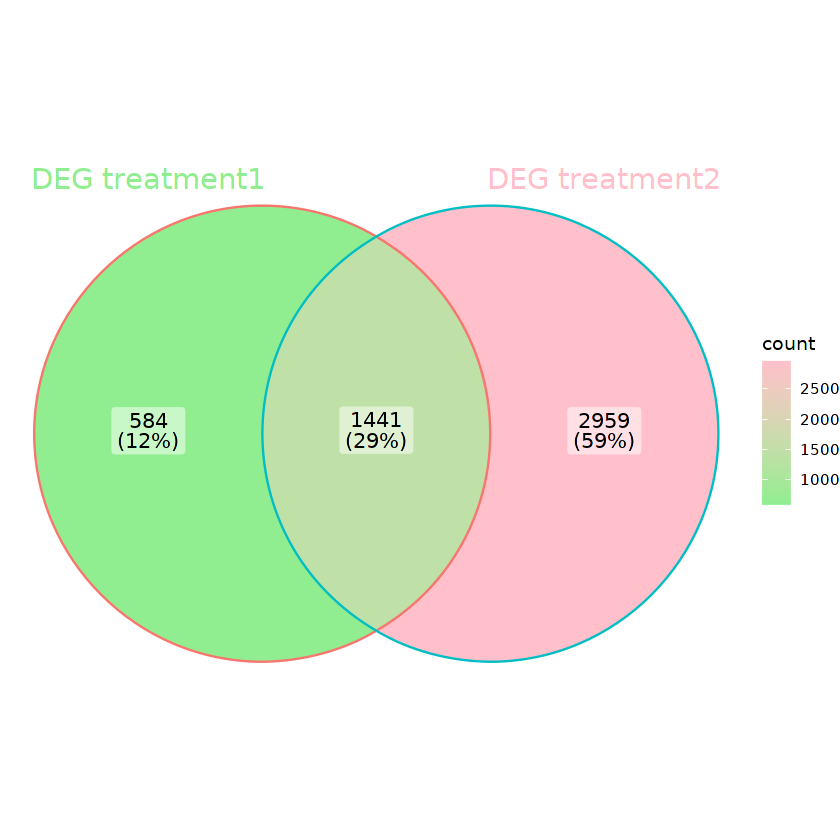

```r
ggVennDiagram(Venn,
              label.alpha=0.5,
              category.names = c("DEG treatment1", "DEG treatment2"),
              set_color = c("light green", "pink"),
              set_size= 6,
              color= c("row1"="light green", "row2"="light blue")) +
          ggplot2::scale_fill_gradient(low="light green",high = "pink")
ggsave(filename="BMDM_venn_diagram.pdf")
```

## Assing gene symbols to gene IDs

Now that we have found the DEGs, we have to associate the gene symbols to the ENSEMBL IDs to get the DEGs names. To do so, we have to use the same annotated version of the genome that researchers have used to obtain the counts. In this case, the authors have used the GRCm38 genome reference for Mus musculus.

Libraries required for the analysis are from Bioconductor

```r
library(BiocManager)
library(ensembldb)
library(AnnotationHub)
```

I have used a version of the mouse genome compatible with the one used by the authors (GRCm38 genome). The version 87 (v87) was chosen looking at https://www.ensembl.org/info/website/archives/assembly.html, in which are reported the assembly for different species. Considering mouse species, and the GRCm38 genome annotation used by the authors, version 87, released in December 2016, was selected for the analysis.

```r
Ann.Hub <- AnnotationHub()
```

```
snapshotDate(): 2021-10-20
```

I load on Ann.Hub the Mus musculus EnsDb v87

```r
Ann.Hub.Db <- query(Ann.Hub, pattern= c("Mus musculus", "EnsDb", 87))
```

```r
Ann.Hub.Edb <- Ann.Hub.Db[[1]]
```

```
loading from cache
```

I select the rows of the dataframe that contains the DEGs between control and samples treated with IL-4 and IL-13 and save them in the object ENSMUSG

```r
ENSMUSG <- rownames(int.res.df)
```

I add the gene symbols associated to the gene IDs in a new column of the dataframe int.res.df named symbol. To assign the gene ID to the gene symbol I write a function that is applied to the object ENSMUSG (that are the rownames, so the gene ID, of the DEGs between controls and IL-4 and -13 treated samples). The function uses the annotated version of the genome saved into Ann.Hub.Edb and filters for the gene names associated to the gene ID contained in the object ENSMUSG. Then, the results are saved in a new column of the dataframe int.res.df named symbol, and that contains the gene symbols associated to the gene IDs.

```r
int.res.df$symbol <- unlist(lapply(ENSMUSG,function(x){
    genes(Ann.Hub.Edb,filter = GeneIdFilter(x))$gene_name}
                                  ))
```

```r
head(int.res.df)
```

A data.frame: 6 × 7

|  | baseMean <dbl> | log2FoldChange <dbl> | lfcSE <dbl> | stat <dbl> | pvalue <dbl> | padj <dbl> | symbol <chr> |
| --- | --- | --- | --- | --- | --- | --- | --- |
| ENSMUSG00000000028 | 369.927216 | 1.033901 | 0.4312741 | 2.397318 | 1.651557e-02 | 4.489269e-02 | Cdc45 |
| ENSMUSG00000000037 | 10.029005 | 1.159392 | 0.4765520 | 2.432877 | 1.497940e-02 | 4.137967e-02 | Scml2 |
| ENSMUSG00000000126 | 9.987519 | 1.491952 | 0.4061517 | 3.673387 | 2.393567e-04 | 1.083079e-03 | Wnt9a |
| ENSMUSG00000000202 | 44.199900 | 4.161619 | 0.3380655 | 12.310098 | 7.992606e-35 | 4.056456e-33 | Btbd17 |
| ENSMUSG00000000204 | 14.248547 | -1.605387 | 0.3285038 | -4.886967 | 1.024011e-06 | 7.160730e-06 | Slfn4 |
| ENSMUSG00000000247 | 29.381890 | 2.124690 | 0.4218556 | 5.036533 | 4.740384e-07 | 3.502098e-06 | Lhx2 |

I select the rows of the dataframe that contains the DEGs between control and samples treated with IL-4, IL-13 and TNFα and save them into the object ENSMUS

```r
ENSMUS <- rownames(tnf.res.df)
```

Then I appply the same function described before to have as a result the gene symbols associated to the gene IDs in a new column of the dataframe tnf.res.df named symbol

```r
tnf.res.df$symbol <- unlist(lapply(ENSMUS,function(x){
    genes(Ann.Hub.Edb,filter = GeneIdFilter(x))$gene_name}))
```

```r
head(tnf.res.df)
```

A data.frame: 6 × 7

|  | baseMean <dbl> | log2FoldChange <dbl> | lfcSE <dbl> | stat <dbl> | pvalue <dbl> | padj <dbl> | symbol <chr> |
| --- | --- | --- | --- | --- | --- | --- | --- |
| ENSMUSG00000000028 | 169.382647 | -1.008014 | 0.37412806 | -2.694301 | 7.053634e-03 | 1.700811e-02 | Cdc45 |
| ENSMUSG00000000056 | 532.994855 | -1.203418 | 0.08286574 | -14.522498 | 8.727077e-48 | 1.830957e-46 | Narf |
| ENSMUSG00000000085 | 375.300194 | -1.171186 | 0.07650790 | -15.308039 | 6.757019e-53 | 1.590152e-51 | Scmh1 |
| ENSMUSG00000000088 | 2530.809715 | 1.847942 | 0.10329525 | 17.889900 | 1.413613e-71 | 4.713244e-70 | Cox5a |
| ENSMUSG00000000093 | 5.537536 | -2.160345 | 0.59790515 | -3.613189 | 3.024535e-04 | 8.753596e-04 | Tbx2 |
| ENSMUSG00000000149 | 5454.803981 | -1.162582 | 0.09038619 | -12.862386 | 7.327942e-38 | 1.212583e-36 | Gna12 |

```r
library(EnhancedVolcano)
```

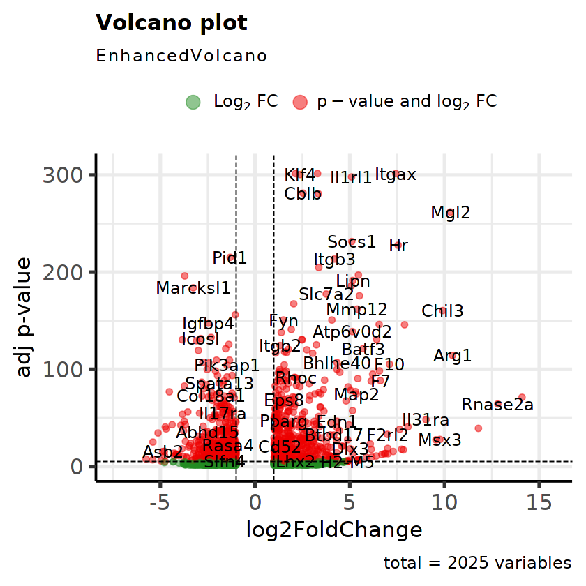

```r
EnhancedVolcano(int.res.df, x="log2FoldChange", y="padj", lab=int.res.df$symbol, xlab= "log2FoldChange", ylab="adj p-value")
ggsave(filename="BMDM_Volcano.int.pdf")
```

###### Volcano plot of DEGs between controls and IL-4 and -13 treated sample

The same has also been done for the tnf.res.df. I save the Volcano plot corresponding to the DE of control VS IL-4, IL-13 and TNFα treatment in the BMDM_Volcano.tnf.pdf file

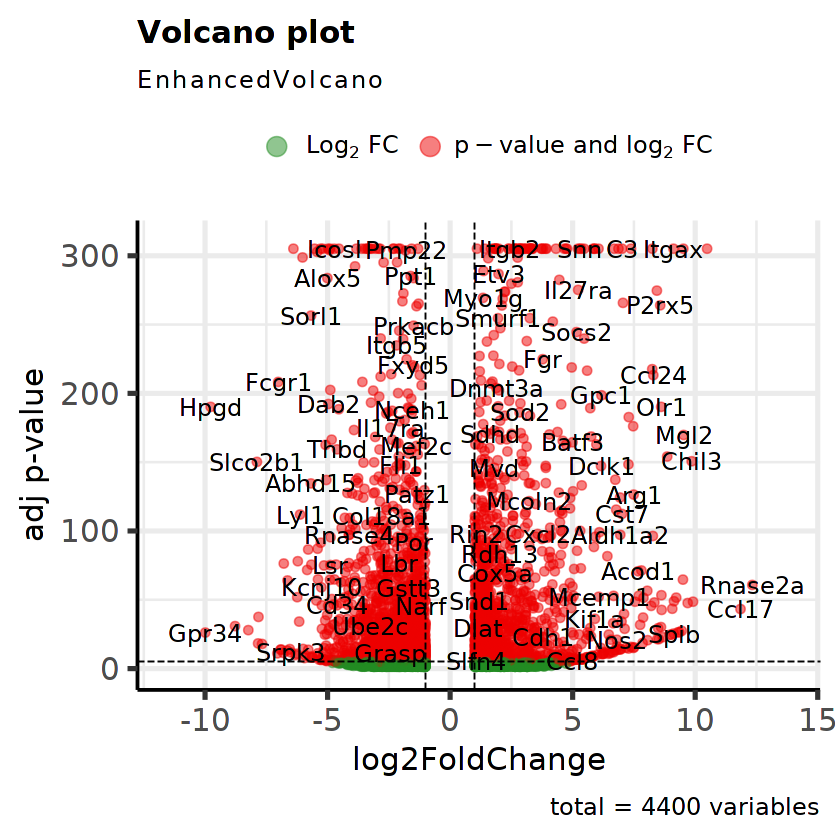

```r
EnhancedVolcano(tnf.res.df, x="log2FoldChange", y="padj", lab=tnf.res.df$symbol, xlab= "log2FoldChange", ylab="adj p-value")
ggsave(filename="BMDM_Volcano.tnf.pdf")
```

###### Volcano plot of DEGs between controls and IL-4, -13 and TNFα treated samples

In both Volcano plots, we have on the y-axis the adjusted p-value and on the x-axis the log2foldchange differences. Both values have been computed during the DE analysis perfomed using DESeq2 package by Bioconductor.

Moreover, genes that are less expressed (downregulated) are represented on the left part of the graph, corresponding to negative log2foldchange values, instead genes more expressed (upregulated) are represented on the right part of the graph, corresponding to positive log2foldchange values. The more the dots are near to 0 log2foldchange values, the less they are up- or downregulated, and the opposite is true if considering the genes further from 0. It is interesting to notice that in both experimental conditions, we have more genes that are upregulated compared to the downregulated. Also, the most significant DEGs are represented on top of the Volcano plot.

## Enriched functional features

So far, we have found the DEGs between our experimental conditions and named the genes. However, we do not know nothing about the biological processes in which these genes are involved, that is of great importance in trying to understand which will be the biological implications of the treatment administered. To infer the biological processes, I have used Gene Ontology (GO) database (http://geneontology.org/), which assigns to each provided gene name an ontology annotation, that correlates with the function of the gene products. There are 3 different ontologies (cellular components (CP), molecular functions (MF), biological process (BP)). For the aim of this project, I have used the biological process ontology, since it provides the ontology annotation for a bunch of molecular events linked to the execution of genetically-encoded biological products or programs.

First, I have selected for the DEGs positively regulated for both cases (control VS IL-4 and IL-13 treatment and control VS IL-4, IL-13 and TNFα treatment presenting logFC >0) and the same was done selecting for the DEGs negatively regulated (with logFC<0) using the dplyr package.

```r
library(dplyr)
positive.ctrl.int <- dplyr::filter(int.res.df, log2FoldChange >0)
negative.ctrl.int <- dplyr::filter(int.res.df, log2FoldChange <0)
positive.ctrl.tnf <- dplyr::filter(tnf.res.df, log2FoldChange >0)
negative.ctrl.tnf <- dplyr::filter(tnf.res.df, log2FoldChange <0)
```

Then, I have saved into a txt file the gene names of the positively and negatively regulated DEGs for both treatment conditions.

```r
pos.DEG.int <- positive.ctrl.int$symbol
neg.DEG.int <- negative.ctrl.int$symbol
pos.DEG.tnf <- positive.ctrl.tnf$symbol
neg.DEG.tnf <- negative.ctrl.tnf$symbol

writeLines(pos.DEG.int, "pos.DEG.int.txt")
writeLines(neg.DEG.int, "neg.DEG.int.txt")
writeLines(pos.DEG.tnf, "pos.DEG.tnf.txt")
writeLines(neg.DEG.tnf, "neg.DEG.tnf.txt")
```

Using the gene symbols contained in the indicated txt files, I have performed a GO analysis on the GO website (http://geneontology.org/), so that I have performed 4 GO analyses copying and pasting the gene symbols from the 4 different files and using as ontology biological processes. I have downloaded the results as table format txt files, that are present inside the working directory with the names "posdegint.txt", "negdegint.txt", posdegtnf.txt" and "negdegtnf.txt". From these data I have made a graphical visualization of the top 20 enriched biological processes using the library ggplot2.

```r
library(ggplot2)
```

I have converted the data contained in each txt file downloaded from GO website into dataframes

```r
GO_data1 <- read.table(file="posdegint.txt", sep="\t", header=T)
GO_data2 <- read.table(file="negdegint.txt", sep="\t", header=T)
GO_data3 <- read.table(file="posdegtnf.txt", sep="\t", header=T)
GO_data4 <- read.table(file="negdegtnf.txt", sep="\t", header=T)
```

For each dataframe, I have selected the columns related to the biological process ontology, the enriched fold change, that represents how much the indicated biological process is enriched, and the raw p-value, which indicates how much we can be confident that the indicated biological process is truely enriched, log-transformed. For all, I have selected the first 20 rows.

```r
data_ggp1 <- data.frame(GO_data1$GO.biological.process.complete[1:20], GO_data1$upload_1..fold.Enrichment.[1:20], -log(GO_data1$upload_1..raw.P.value.[1:20]))
colnames(data_ggp1) = c("biological_process", "fold_enrichment", "log_p_value")
dim(data_ggp1)

data_ggp2 <- data.frame(GO_data2$GO.biological.process.complete[1:20], GO_data2$upload_1..fold.Enrichment.[1:20], -log(GO_data2$upload_1..raw.P.value.[1:20]))
colnames(data_ggp2) = c("biological_process", "fold_enrichment", "log_p_value")
dim(data_ggp2)

data_ggp3 <- data.frame(GO_data3$GO.biological.process.complete[1:20], GO_data3$upload_1..fold.Enrichment.[1:20], -log(GO_data3$upload_1..raw.P.value.[1:20]))
colnames(data_ggp3) = c("biological_process", "fold_enrichment", "log_p_value")
dim(data_ggp3)

data_ggp4 <- data.frame(GO_data4$GO.biological.process.complete[1:20], GO_data4$upload_1..fold.Enrichment.[1:20], -log(GO_data4$upload_1..raw.P.value.[1:20]))
colnames(data_ggp4) = c("biological_process", "fold_enrichment", "log_p_value")
dim(data_ggp4)

head(data_ggp2)
```

1. 20

2. 3

1. 20

2. 3

1. 20

2. 3

1. 20

2. 3

A data.frame: 6 × 3

|  | biological_process <chr> | fold_enrichment <chr> | log_p_value <dbl> |
| --- | --- | --- | --- |
| 1 | negative regulation of cGAS/STING signaling pathway (GO:0160049) | 24.17 | 6.776727 |
| 2 | positive regulation of toll-like receptor signaling pathway (GO:0034123) | 19.34 | 8.232014 |
| 3 | regulation of the force of heart contraction by chemical signal (GO:0003057) | 13.81 | 7.333933 |
| 4 | cytolysis in another organism (GO:0051715) | 13.81 | 7.333933 |
| 5 | positive regulation of blood pressure by epinephrine-norepinephrine (GO:0003321) | 13.81 | 7.333933 |
| 6 | heat generation (GO:0031649) | 12.09 | 8.463652 |

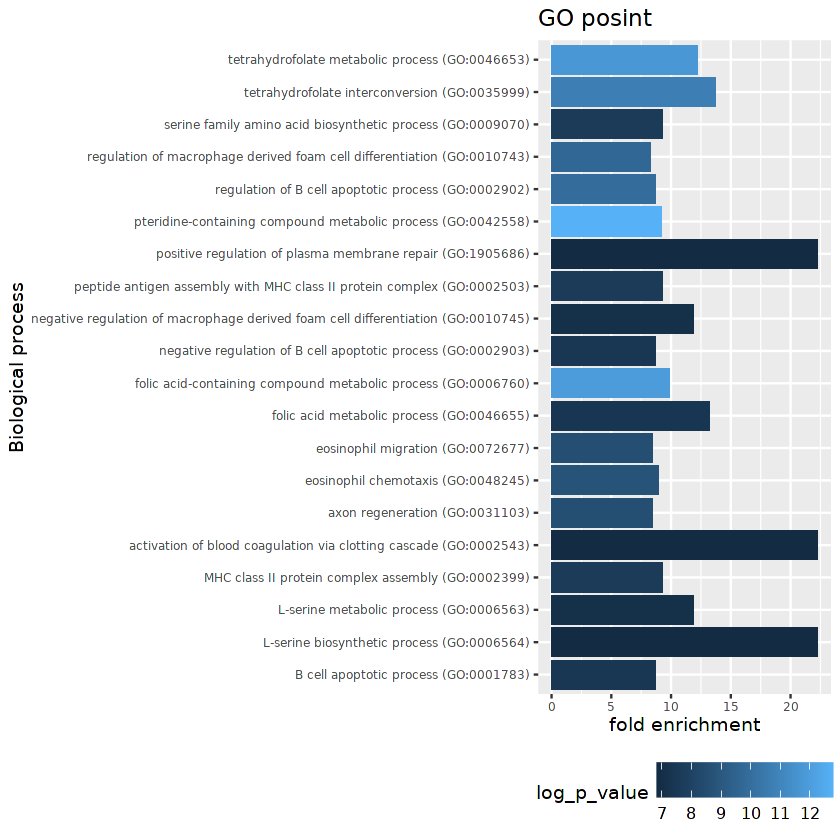

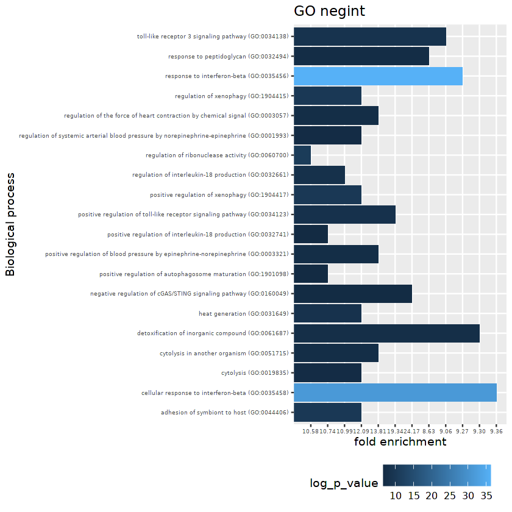

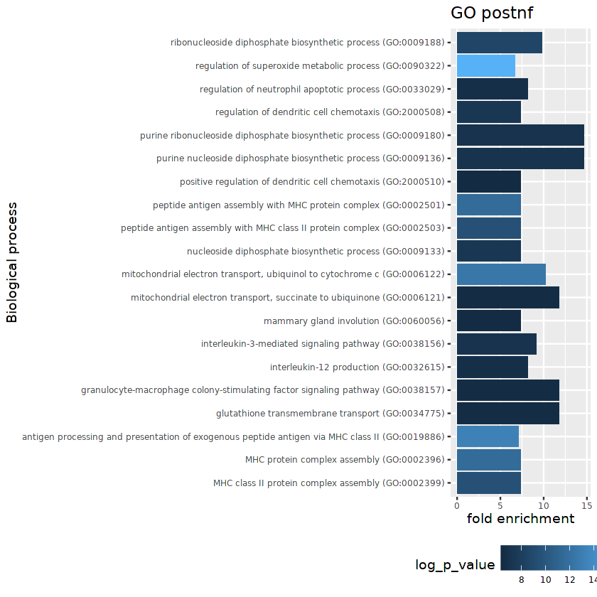

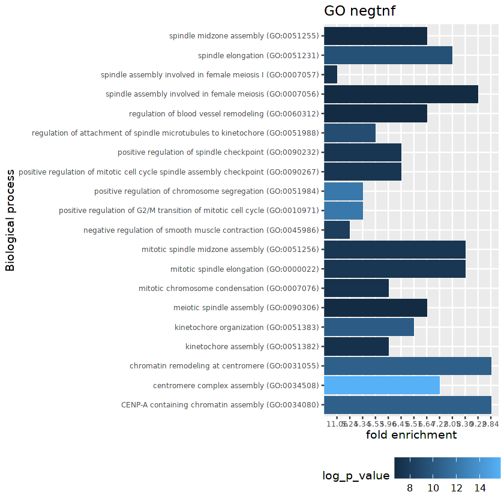

```r
ggplot(data_ggp1) +
  geom_bar(stat = "identity",
           aes(y=fold_enrichment,x=biological_process, fill=log_p_value)) +
  labs(fill="log_p_value") +
  theme(legend.position =c("bottom"),
        legend.box="horizontal",
        legend.text = element_text(size = 9),
        legend.key.height = unit(0.75, "cm"),
        legend.key.width = unit(0.75, "cm"),
        axis.text=element_text(size=7)) +
  scale_x_discrete() +
  labs(title="GO posint",
       y="fold enrichment",
       x="Biological process") +
  coord_flip()
ggsave(filename="BMDM_GOposdegint.pdf")


ggplot(data_ggp2) +
  geom_bar(stat = "identity",
           aes(y=fold_enrichment,x=biological_process, fill=log_p_value)) +
  labs(fill="log_p_value") +
  theme(legend.position =c("bottom"),
        legend.box="horizontal",
        legend.text = element_text(size = 9),
        legend.key.height = unit(0.75, "cm"),
        legend.key.width = unit(0.75, "cm"),
        axis.text=element_text(size=5)) +
  scale_x_discrete() +
  labs(title="GO negint",
       y="fold enrichment",
       x="Biological process") +
  coord_flip()
ggsave(filename="BMDM_GOnegdegint.pdf")


ggplot(data_ggp3) +
  geom_bar(stat = "identity",
           aes(y=fold_enrichment,x=biological_process, fill=log_p_value)) +
  labs(fill="log_p_value") +
  theme(legend.position =c("bottom"),
        legend.box="horizontal",
        legend.text = element_text(size = 7),
        legend.key.height = unit(0.75, "cm"),
        legend.key.width = unit(0.75, "cm"),
        axis.text=element_text(size=7)) +
  scale_x_discrete() +
  labs(title="GO postnf",
       y="fold enrichment",
       x="Biological process") +
  coord_flip()
ggsave(filename="BMDM_GOposdegtnf.pdf")


ggplot(data_ggp4) +
  geom_bar(stat = "identity",
           aes(y=fold_enrichment,x=biological_process, fill=log_p_value)) +
  labs(fill="log_p_value") +
  theme(legend.position =c("bottom"),
        legend.box="horizontal",
        legend.text = element_text(size = 9),
        legend.key.height = unit(0.75, "cm"),
        legend.key.width = unit(0.75, "cm"),
        axis.text=element_text(size=7)) +
  scale_x_discrete() +
  labs(title="GO negtnf",
       y="fold enrichment",
       x="Biological process") +
  coord_flip()
ggsave(filename="BMDM_GOnegdegtnf.pdf")
```

Considering the results of the GO analysis, we can have different biological processes found correlated to:

1. **positively regulated DEGs in BMDMs treated with IL-4 and IL-13**: tetrahydrofolate and folic acid metabolism; serine metabolism; eosinophil chemotaxis and migration; repair processes (such as axon regeneration, activation of the clotting cascade and plasma membrane repair); regulation of B cells apoptotic processes; MHC class II-peptide antigen complex assembly (as reported in the image below, taken from the corresponding pdf).
2. **negatively regulated DEGs in BMDMs treated with IL-4 and IL-13**: regulation and response to external pathogens and innate immune signals related to inflammatory processes (such as response to interferon-beta, response to peptidoglycans, regulation of cGAS/STING signaling pathway, etc.) and processes associated to recognition and phagocytosis-like elimination processes (such as adhesion of symbiont to host, autophagosome maturation, cytolysis, etc.) (as reported in the image below, taken from the corresponding pdf).
3. **positively regulated DEGs in BMDMs treated with IL-4, IL-13 and TNFα**: MHC class II assembly, antigen processing and presentation; ribonucleoside diphosphate metabolism; dendritic cell chemotaxis; neutrophil apoptosis; interleukin signaling pathways and production (such as IL-12, -3 and granulocyte−macrophage colony−stimulating factor (GM-CSF)) (as reported in the image below, taken from the corresponding pdf).
4. **negatively regulated DEGs in BMDMs treated with IL-4, IL-13 and TNFα**: mitotic division, particularly on spindle assembly; kinetocore organization and chromatin remodeling at the centromere (as reported in the image below, taken from the corresponding pdf).

# Discussion

In the present study, reaserchers treated BMDMs with different combinations of interleukins to evaluate the different activation states that BMDMs cultured in vitro could assume. In fact, as also discussed in the Introduction, macrophages can undergo different types of activations depending on the different factors (such as interleukins and cytokines) that are present in the environment. Depending on the type of stimulus, this innate immune cell population can be differently activated and acquires different features and functions. For example, macrophages can acquire either repair-like or pro-inflammatory signatures upon different stimulation. The authors wanted to dissect whether possible intermediate acitvation states can be assumed by macrophages if different combinations of stimuli are provided.

To answer this question, the authors analyzed 3 different conditions: control (untreated BMDMs), BMDMs treated with IL-4 and -13 (treatment1) and BMDMs treated with IL-4, -13 and TNFα. Then, bulk RNA-sequencing experiment was performed to discover which genes are differentially expressed between the different treatment conditions. In my work, I have performed a differential expression analysis starting from the raw counts obtained from the bulk RNA-seq experiment. Once identified the DEGs in the treatent conditions compared to controls, I analyzed to which biological processes the up- or downregulated genes are associated to, in order to get information about which could be the possible activation states assumed by BMDMs once sensing the presence of the indicated interleukins.

Analysing the results of the GO analysis, it is not surprising to notice that the positively regulated DEGs in BMDMs treated with IL-4 and IL-13 are associated to biological processes correlated to repair and heal, and that instead the negatively regulated DEGs upon the same treatment conditions are mainly associated to inflammatory processes and response to external harmful stimuli such as pathogens and microbes. In fact, IL-4 and -13 are very well characterized interleukins involved in the alternative activation of macrophages. M2 macrophages in this way activated play important roles in the recovering of homeostatic conditions after inflammation, so that in repair and healing, and they loose the pro-inflammatory function. Also, eosinophil chemotaxis and migration is another biological process associated to the upregulated genes once IL-4 and -13 are given to BMDMs. Eosinophils are immune cells not ony involved in allergic reactions and defense against parasites, but also in modulation of inflammation, immunoregulation, tissue remodeling and repair. This result suggest that not only macrophages get activated to repair the damaged tissues, but also that they could recruit other immune cell populations that cooperate in this process.

Other biological processes associated to positively regulated DEGs in BMDMs treated with IL-4 and IL-13 are also related to serine, folic acid and tetrahydrofolate metabolism. These metabolic pathways are strictly interconnected with each other, since one provides the substrates to be used for the other. Overall, they play an important role in the one-carbon unit transfer process, that is pivotal for nucleotides biosynthesis, particularly of thymidine. These data suggest that once IL-4 and -13 are administered, the genes related to DNA synthesis (and presumably to cell replication) are upregulated, so the repair-like macrophages are increasing in number to mediate the recovery of homeostasis after infection.

Considering instead the the biological processes associated to positively regulated DEGs in BMDMs treated with IL-4, IL-13 and TNFα, it is possible to notice that ribonucleoside diphosphate metabolism is enriched, suggesting that the RNA synthesis is upregulated once the indicated treatment conditions are applied. This could correlate with the fact that many signaling pathways in response to or involved in the production of different cytokines and interelukins are also found associated to the upregulated genes once IL-4, IL-13 and TNFα are administered to BMDMs. In fact, IL-12 production can be found, as well as also IL-3 and granulocyte-macrophages colony stimulating factors (GM-CSF). IL-12, once produced, is able to mediate the differentiation of naive T cells into TH1 cells, that in turn produce IFNγ. IFNγ is sensed by macrophages, that become activated and assume pro-inflammatory functions. Moreover, IL-3 and GM-CSF once produced regulate the inflammatory response in order to clear pathogens by changing the abundance of various cell populations. Overall, these data highlight the fact BMDMs treated with IL-4, -13 and TNFα assume a pro-inflammatory function, that anti-correlates with the downregulation of the same biological function once BMDMs are treated only with IL-4 and -13.

Moreover, also MHC class II-antigen assembly, processing and presentation are biological processes asociated to positively regulated DEGs in BMDMs treated with IL-4, IL-13 and TNFα, suggesting that BMDMs (together with antigen-presenting cells that are as well recruited - see the biological process "dendritic cell chemotaxis") present the antigens to CD4+ T cells, that in turn are able to activate B cells to produce antibodies and differentiate into memory T cells. By doing so, not only macrophages are involved in the process of inflammation, but also they contribute to the immune memory formation.

Finally, negatively regulated DEGs in BMDMs treated with IL-4, IL-13 and TNFα are enriched in biological processes mainly related to mitotic cell division, suggesting that the pro-inflammatory macrophages are not able to replicate themselves, contrary to what is observed once we treat BMDMs with IL-4 and -13.

Overall, these results suggest that once BMDMs are treated with IL-4 and IL-13 they are alternatively activated and assume signatures related to repair, healing and replication, loosing the pro-inflammatory phenotype. Instead, when also TNFα is added to the previously mentioned interleukins as a treatment combination, BMDMs are mainly involved in inflammation and immune memory, but they cannot replicate. Therefore, this study indentified a class of macrophages that are alternatively activated, so that can be defined M2 macrophages, once IL-4 and -13 are given, and a second activation status more similar to a classical activation once IL-4, -13 and TNFα are added.

These results could present important therapeutical applications in many different fields. First of all, knowing which kind of effects the presence of the different cytokines can have on macrophages could provide new biological targets against which develop some molecular therapies, such as antibodies. For example, different TNFα blockers have been developed to treat rheumatoid arthritis and other kind of autoimmune disorders such as inflammatory bowel disease, ankylosing spondylitis and psoriasis. As already explained, TNFα mediates the classical activation of macrophages, that assume pro-inflammatory roles. In a context of inflammation such as the diseases mentioned, blocking an increased inflammtory status given by this immune cell population could represent a benefit for the patients (Parameswaran N. et al., 2010). Also, defining the type of interleukins present in the tumor microenvironment could shed light on the role of tumor-associated macrophages. The classical activated macrophages (due to the presence of IL-4, -13 and TNFα) could play a role in inflammation and immune memory acquisition, and so a positive role in tumor eradication. However, the alternativly activated macrophages could be involved in immune response deactivation in the tumor microenvironment, thus promoting tumor growth. Finally, alternatively activated macrophages could play beneficial functions in atherosclerosis, since evidencies suggest that they could can promote plaque stability by favouring fibrous-cap formation, thereby reducing the risk of rupture and local thrombosis (Gordon S., 2003).

In conclusion, investigating the different activation statuses that can be acquired once different combinations of interleukins are given to macrophages could be of great importance to dissect which could be the possible functions played by this complex immune cell population, and exploit them in a therapeutic perspective. Further studies are needed to confirm whether the biological processes associated to different treatment conditions are also present in vivo.

# References

1. Gordon, S., Taylor, P. Monocyte and macrophage heterogeneity. *Nat Rev Immunol 5*, 953–964 (2005).
2. Ginhoux F, Guilliams M. Tissue-Resident Macrophage Ontogeny and Homeostasis. *Immunity*, 2016
3. Molgora M, Supino D, Mavilio D, Santoni A, Moretta L, et al. The yin-yang of the interaction between myelomonocytic cells and NK cells. Scand J Immunol, 2018
4. Garlanda C, Bottazzi B, Bastone A, Mantovani A. Pentraxins at the crossroads between innate immunity, inflammation, matrix deposition, and female fertility. *Annu Rev Immunol*, 2005
5. Locati M, Curtale G, Mantovani A. Diversity, Mechanisms, and Significance of Macrophage Plasticity. *Annu Rev Pathol*. 2020 Jan 24
6. Taylor, P. R. et al. Macrophage receptors and immune recognition. *Annu. Rev. Immunol.* 23
7. Biswas, S. K., and Mantovani, A. (2010). Macrophage plasticity and interaction with lymphocyte subsets: cancer as a paradigm. *Nat. Immunol.* 11
8. Parameswaran N, Patial S. Tumor necrosis factor-α signaling in macrophages. *Crit Rev Eukaryot Gene Expr*, 2010
9. Yarilina A, Park-Min KH, Antoniv T, Hu X, Ivashkiv LB. TNF activates an IRF1-dependent autocrine loop leading to sustained expression of chemokines and STAT1-dependent type I interferon-response genes. *Nat Immunol*, 2008
10. Gordon, S. Alternative activation of macrophages. *Nat Rev Immunol* 3, 23–35, 2003
11. Mills CD. M1 and M2 Macrophages: Oracles of Health and Disease. *Critical Reviews in Immunology*, 2012